# TIPS DATASET

# 17. How do we interpret precision, recall, and F1-score in the context of survival prediction?

## In the context of survival prediction, precision, recall, and F1-score are important evaluation metrics that provide insights into the performance of a machine learning model. Here's how to interpret these metrics in the context of survival prediction:

Precision: Interpretation: Precision measures the proportion of correctly predicted survivors among all the instances predicted as survivors by the model. Context: A high precision indicates that when the model predicts an individual as a survivor, it is likely to be correct. In other words, the model minimizes false positive predictions of survival. Importance: Precision is crucial when making predictions has consequences, such as resource allocation for rescue operations. High precision means fewer resources wasted on false positives.

### Recall (Sensitivity):

Interpretation: Recall measures the proportion of correctly predicted survivors among all the actual survivors in the dataset. Context: High recall implies that the model is good at capturing most of the actual survivors. It minimizes false negatives, ensuring that a high percentage of survivors are correctly identified. Importance: Recall is essential when identifying survivors is critical, such as in medical diagnoses or search and rescue operations. High recall ensures that very few true survivors are missed.

### F1-Score:

Interpretation: The F1-Score is the harmonic mean of precision and recall. It provides a balance between the two metrics. Context: F1-Score considers both false positives (precision) and false negatives (recall). It represents a trade-off between identifying as many survivors as possible while avoiding false alarms.

#### Importance: F1-Score is useful when there is an inherent trade-off between precision and recall, and you want to strike a balance between minimizing false positives and false negatives.

In the context of survival prediction, the interpretation of these metrics depends on the specific goals and consequences of the task. The choice of which metric to prioritize (precision, recall, or F1-Score) depends on the relative importance of false positives and false negatives in your application.

If false positives (incorrectly predicting survival) have significant consequences, prioritize precision. If false negatives (missing actual survivors) have significant consequences, prioritize recall. If there's a balance to be struck between the two types of errors, consider the F1-Score.

In practice, it's often helpful to look at the entire confusion matrix, which includes true positives, true negatives, false positives, and false negatives, to gain a more comprehensive understanding of model performance and make informed decisions about the model's suitability for a specific application.

Advanced Analysis:

# 18. How can we apply feature engineering to improve model performance (e.g., title extraction from names)?

### Feature engineering is a crucial step in improving model performance by creating new features or transforming existing ones to provide more valuable information to the model. In the context of survival prediction for the Titanic dataset, here are some feature engineering techniques you can apply:

Title Extraction from Names: Extract titles (e.g., Mr., Mrs., Miss, etc.) from passenger names. Titles can provide information about social status and gender, which might be relevant for survival prediction. Group rare or similar titles into broader categories to reduce feature dimensionality.

#### Family Size: Create a new feature that represents family size by combining the number of siblings/spouses (SibSp) and parents/children (Parch) on board. Larger families might have different survival rates.

Alone Status: Create a binary feature to indicate whether a passenger is traveling alone (1) or with family (0). Solo travelers might have different survival characteristics.

#### Cabin Deck: Extract the deck information from the cabin numbers. Passengers on certain decks may have been closer to lifeboats, impacting their survival chances.

#### Ticket Prefix: Extract prefixes from ticket numbers. Some prefixes may indicate group bookings or special arrangements.

Age Binning: Group passengers into age bins (e.g., children, adults, seniors) to capture nonlinearities in age-related survival rates.

#### Fare Binning: Group fares into bins to capture variations in fare ranges and reduce the impact of extreme values.

#### Name Length: Create a feature representing the length of passenger names. Longer names might indicate a higher social status.

#### Age * Class Interaction: Create a new feature by multiplying age and passenger class (Pclass). This captures the interaction between age and class in survival prediction.

#### Title * Age Interaction: Create a new feature by multiplying passenger titles and age. This may capture unique age-related survival patterns for different titles.

#### Age Group * Pclass Interaction: Create an interaction feature that combines age groups and passenger class. This might capture survival trends specific to age groups within each class.

One-Hot Encoding: Encode categorical variables such as gender (sex) and port of embarkation (embarked) using one-hot encoding. Missing Value Handling: Handle missing values in features like age and cabin. You can impute missing values with median values or use more advanced techniques like regression imputation. Log Transformation: If necessary, apply log transformation to features with skewed distributions to make them more suitable for modeling. After creating these engineered features, it's essential to assess their impact on model performance through experimentation and cross-validation. Some features may significantly improve the model, while others may not add value or might introduce noise. Feature engineering is an iterative process, and you should continuously evaluate and refine your features to achieve the best model performance.

# 19. Can we build an ensemble of models for better predictive accuracy?

1. Can we build an ensemble of models for better predictive accuracy? #### Yes, building an ensemble of models is a common and effective approach to improve predictive accuracy in machine learning. Ensembling combines the predictions of multiple individual models to make more accurate and robust predictions. In the context of survival prediction for the Titanic dataset, you can certainly build an ensemble of models to achieve better predictive accuracy. Here are some ensemble techniques you can consider:

##### Voting Ensemble:

```
Create an ensemble of multiple machine learning models (e.g., decision trees, random forests, support vector machines, logistic regression).
Use majority voting (for classification) to make final predictions. Each model gets one vote, and the class with the most votes is the predicted class.
```

##### Bagging (Bootstrap Aggregating):

```
Bagging involves training multiple instances of the same model on different subsets of the training data.
Popular algorithms like Random Forests use bagging by training multiple decision trees on bootstrapped subsets of the data and combining their predictions.
```

##### Boosting:

```
Boosting focuses on training multiple weak learners (e.g., shallow decision trees) sequentially, with each learner correcting the errors of the previous one.
Algorithms like AdaBoost and Gradient Boosting are common boosting techniques.
```

##### Stacking:

```
Stacking combines the predictions of multiple models by training a meta-model (often a simple linear model) on their outputs.
It involves a two-level architecture: base models at the first level and a meta-model at the second level.
```

##### XGBoost and LightGBM:

```
XGBoost (Extreme Gradient Boosting) and LightGBM are gradient boosting libraries known for their high predictive accuracy.
They can be used as standalone models or as part of an ensemble.
```

##### Ensemble with Feature Selection:

```
Combine models while selecting only the most important features for each model. This can help improve predictive accuracy while reducing dimensionality.
```

##### Ensemble with Different Algorithms:

```
Combine models that use different algorithms to capture different patterns in the data.
For example, combine a tree-based model (e.g., Random Forest) with a linear model (e.g., Logistic Regression).
```

##### Ensemble with Hyperparameter Tuning:

```
Perform hyperparameter tuning for each model in the ensemble to optimize their individual performance.
```

##### Ensemble with Model Stacking:

```
Create multiple levels of ensembling by stacking multiple layers of models on top of each other.
This can be computationally expensive but may provide further performance gains.
```

When building an ensemble of models, it's important to ensure diversity among the base models. Diversity in terms of algorithms, hyperparameters, and feature subsets can lead to more robust and accurate ensemble predictions.

Additionally, you should use cross-validation to evaluate the performance of your ensemble. Cross-validation helps assess how well the ensemble generalizes to unseen data and can guide the selection of the best combination of models and techniques for your specific problem.

Ensembling is a powerful technique that often leads to improved predictive accuracy, making it a valuable tool for tackling complex machine learning tasks like survival prediction on the Titanic dataset.

# 20. What techniques can we use for interpreting and visualizing model predictions?

Interpreting and visualizing model predictions are essential steps in understanding how a machine learning model makes decisions and gaining insights into its behavior. Here are some techniques and tools you can use to interpret and visualize model predictions:

Feature Importance:

Techniques:

For tree-based models (e.g., Random Forest, Decision Trees), you can calculate feature importance scores, which indicate the influence of each feature on model predictions. Permutation Importance: Shuffle the values of a feature and measure how much it affects the model's performance. SHAP (SHapley Additive exPlanations): SHAP values provide a unified measure of feature importance for a wide range of models.

Visualization:

Create bar charts or heatmaps to visualize feature importance scores. Plot individual SHAP values to understand the impact of each feature on specific predictions. Partial Dependence Plots (PDP):

Techniques:

PDPs show how a feature's values affect model predictions while keeping other features constant. They help reveal the relationship between a feature and the predicted outcome. Visualization:

Plot PDPs for selected features to visualize how they influence predictions. Residual Plots:

Techniques:

For regression models, residual plots show the distribution of residuals (the difference between predicted and actual values). Patterns in residuals can provide insights into model performance. Visualization:

Create scatter plots or histograms of residuals to check for patterns or heteroscedasticity. Confusion Matrix:

Techniques:

For classification models, confusion matrices provide a breakdown of true positives, true negatives, false positives, and false negatives. Visualization:

Create a heatmap or a table to display the confusion matrix. ROC Curve and Precision-Recall Curve:

Techniques:

ROC curves and precision-recall curves help assess the trade-off between true positive rate and false positive rate at different probability thresholds. Visualization:

Plot ROC curves and precision-recall curves to assess model performance. LIME (Local Interpretable Model-agnostic Explanations):

Techniques:

LIME generates local explanations for individual predictions by fitting a simpler interpretable model to a neighborhood of data points. Visualization:

Visualize LIME explanations to understand why the model made a specific prediction for a particular instance. SHAP Plots:

Techniques:

SHAP values can be used to create summary plots that show the overall impact of features on model predictions across a dataset. Visualization:

Plot summary SHAP values to see how features contribute to model predictions globally. Grad-CAM (Gradient-weighted Class Activation Mapping):

Techniques:

For image classification models, Grad-CAM highlights the regions of an image that contribute most to the model's prediction. Visualization:

Overlay the Grad-CAM heatmap on the input image to visualize which areas the model focused on. Model Explanations Libraries:

Techniques:

Various Python libraries, such as interpret, shap, lime, and eli5, offer pre-built tools for interpreting model predictions.

Visualization:

These libraries often come with built-in visualization functions to simplify interpretation. Feature Importance for Regression Coefficients:

Techniques:

For linear regression models, examine the coefficients associated with each feature to understand their impact on the target variable. Visualization:

Create a bar chart or table to display the feature coefficients. These techniques and tools can help you gain insights into your model's behavior, identify potential issues, and improve model transparency. The choice of interpretation and visualization methods depends on the type of model, the nature of the data, and the specific questions you want to answer about your machine learning model's predictions.

# DIEBETIC DATASET

```python
df2 = pd.read_csv('Downloads/diabetes-data.csv')
```

```python
df2
```

|  | Pregnancies | Glucose | BloodPressure | SkinThickness | Insulin | BMI | DiabetesPedigreeFunction | Age | Outcome |
| --- | --- | --- | --- | --- | --- | --- | --- | --- | --- |
| 0 | 6 | 148 | 72 | 35 | 0 | 33.6 | 0.627 | 50 | 1 |
| 1 | 1 | 85 | 66 | 29 | 0 | 26.6 | 0.351 | 31 | 0 |
| 2 | 8 | 183 | 64 | 0 | 0 | 23.3 | 0.672 | 32 | 1 |
| 3 | 1 | 89 | 66 | 23 | 94 | 28.1 | 0.167 | 21 | 0 |
| 4 | 0 | 137 | 40 | 35 | 168 | 43.1 | 2.288 | 33 | 1 |
| ... | ... | ... | ... | ... | ... | ... | ... | ... | ... |
| 763 | 10 | 101 | 76 | 48 | 180 | 32.9 | 0.171 | 63 | 0 |
| 764 | 2 | 122 | 70 | 27 | 0 | 36.8 | 0.340 | 27 | 0 |
| 765 | 5 | 121 | 72 | 23 | 112 | 26.2 | 0.245 | 30 | 0 |
| 766 | 1 | 126 | 60 | 0 | 0 | 30.1 | 0.349 | 47 | 1 |
| 767 | 1 | 93 | 70 | 31 | 0 | 30.4 | 0.315 | 23 | 0 |

768 rows × 9 columns

## 1. How would you explore and visualize class imbalance in the target variable (diabetic vs. non-diabetic) in the diabetes dataset?

```python
class_distribution = df2['Outcome'].value_counts()
print(class_distribution)
```

```
0    500
1    268
Name: Outcome, dtype: int64
```

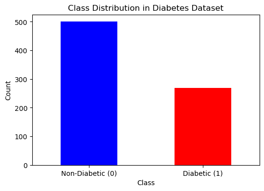

```python
plt.figure(figsize=(6, 4))
class_distribution.plot(kind='bar', color=['blue', 'red'])
plt.title('Class Distribution in Diabetes Dataset')
plt.xlabel('Class')
plt.ylabel('Count')
plt.xticks([0, 1], ['Non-Diabetic (0)', 'Diabetic (1)'], rotation=0)
plt.show()
```

# 2. What methods can you use to detect and address class imbalance in the diabetes dataset?

```python
##Detecting Class Imbalance:

##Check Class Distribution: Calculate and visualize the distribution of the target variable (diabetic vs. non-diabetic)
##to see how many instances belong to each class. Use methods like value_counts() and create bar or pie charts to visualize
##the distribution.

##Calculate Class Ratios: Calculate the ratio of the minority class (diabetic) to the majority class (non-diabetic).
##If this ratio is significantly imbalanced (e.g., 90% non-diabetic and 10% diabetic), it indicates class imbalance.



##Resampling Techniques:

##Oversampling: Increase the number of instances in the minority class by duplicating or generating synthetic samples.
##Common oversampling techniques include Random Oversampling and Synthetic Minority Over-sampling Technique (SMOTE).

##Undersampling: Reduce the number of instances in the majority class by randomly removing samples. Be cautious when
##undersampling, as it may result in loss of information.
```

# 3. How do you handle missing values in the diabetes dataset, especially when they may contain critical medical information?

```python
df2.isnull().sum()
```

```
Pregnancies                 0
Glucose                     0
BloodPressure               0
SkinThickness               0
Insulin                     0
BMI                         0
DiabetesPedigreeFunction    0
Age                         0
Outcome                     0
dtype: int64
```

```python
df2[['Glucose','BloodPressure','SkinThickness','Insulin','BMI']] = df2[['Glucose','BloodPressure','SkinThickness','Insulin','BMI']].replace(0,np.NaN)

print(df2.isnull().sum())
```

```
Pregnancies                   0
Glucose                       5
BloodPressure                35
SkinThickness               227
Insulin                     374
BMI                          11
DiabetesPedigreeFunction      0
Age                           0
Outcome                       0
dtype: int64
```

```python
df2['Glucose'].fillna(df2['Glucose'].mean(), inplace = True)
df2['BloodPressure'].fillna(df2['BloodPressure'].mean(), inplace = True)
df2['SkinThickness'].fillna(df2['SkinThickness'].median(), inplace = True)
df2['Insulin'].fillna(df2['Insulin'].median(), inplace = True)
df2['BMI'].fillna(df2['BMI'].median(), inplace = True)
```

# 1. Can you identify potentially valuable features for predicting diabetes, and how would you create or engineer them from the existing dataset?